# Automating Data-analysis Pipelines

Shaun Jackman

2014-11-03

## Automating Data-analysis Pipelines

UBC [STAT 545A](http://stat545-ubc.github.io/)/STAT 547M  
2014-11-03  
[Shaun Jackman](http://sjackman.ca) [@sjackman](http://twitter.com/sjackman)  
[Jenny Bryan](http://www.stat.ubc.ca/~jenny/) [@JennyBryan](https://twitter.com/JennyBryan)

# Pipelines Automation Dependencies

## Automation

- using [R](http://tryr.codeschool.com/)
- using the [shell](http://en.wikipedia.org/wiki/Shell_script) and [Rscript](https://stat.ethz.ch/R-manual/R-devel/library/utils/html/Rscript.html)
- using make

‘Automating’ comes from the roots ‘auto-’ meaning ‘self-’, and ‘mating’, meaning ‘screwing’.

# Pipelines

## A pipeline

breaks up a monolithic make-all-the-things script into discrete, manageable chunks.

## Each stage of the pipeline

… defines its input and its outputs.  
… does *not* modify its inputs, so it is *idempotent*.

Rerunning a stage of the pipeline  
produces the same results as the previous run.

## Advantage #1

When you modify one stage of the pipeline,  
you don’t have to rerun the entire pipeline.

You only rerun the downstream, dependent stages.

## Advantage #2

Divide up work amongst a group by assigning to each person stages of the pipeline design.

## Advantage #3

You can draw pretty pictures of your pipeline,  
because a pipeline is a graph.

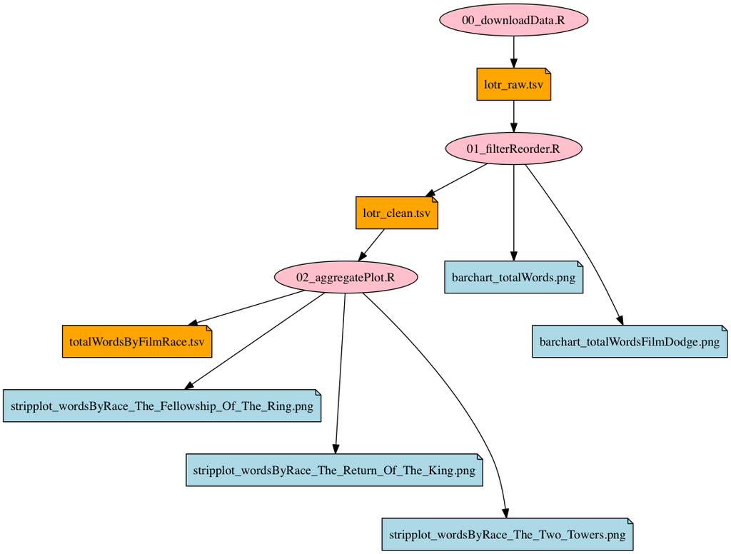

*01_justR*

# Automation

## Automate a pipeline

… to reproduce previous results.  
… to recreate results deleted by fat fingers.  
… to rerun the pipeline with updated software.  
… to run the same pipeline on a new data set.

## Tools

- [R](http://tryr.codeschool.com/)
- the [shell](http://en.wikipedia.org/wiki/Shell_script) and [Rscript](https://stat.ethz.ch/R-manual/R-devel/library/utils/html/Rscript.html)
- make

## R

```r
#!/usr/bin/env Rscript
source("00_downloadData.R")
source("01_filterReorder.R")
source("02_aggregatePlot.R")
```

. . .

- Shows in what order to run the scripts.
- You can resume the pipeline from the middle.

## Shell and Rscript

```bash
#!/bin/sh
set -eux
Rscript 00_downloadData.R
Rscript 01_filterReorder.R
Rscript 02_aggregatePlot.R
```

. . .

Allows you to easily run your pipeline from the shell.

. . .

| Option | Effect |
| --- | --- |
| `set -e` | Stop at the first error |
| `set -u` | Undefined variables are an error |
| `set -x` | Print each command as it is run |

## Mix R scripts with other tools

```bash
#!/bin/sh
set -eux
curl -L http://bit.ly/lotr_raw-tsv >lotr_raw.tsv
Rscript 01_filterReorder.R
Rscript 02_aggregatePlot.R
```

. . .

R is a good tool, but not always the best tool for the job.

Not sacrilege, but the principal tenet of a polyglot.

## Makefile

```
#!/usr/bin/make -f

lotr_raw.tsv:
    curl -L http://bit.ly/lotr_raw-tsv >lotr_raw.tsv

lotr_clean.tsv: 01_filterReorder.R lotr_raw.tsv
    Rscript 01_filterReorder.R

totalWordsByFilmRace.tsv: 02_aggregatePlot.R lotr_clean.tsv
    Rscript 02_aggregatePlot.R
```

. . .

A Makefile gives both the commands  
*and their dependencies*.

## Make is beautiful

Tell Make how to create one type of file from another  
and which files you want to create.

. . .

Make looks at which files you have  
and figures out how to create the files that you want.

# Dependency graph

## A pipeline is a graph

Scripts and data files are vertices of the graph.

Dependencies between stages are edges of the graph.

Both scripts and data files are shown.

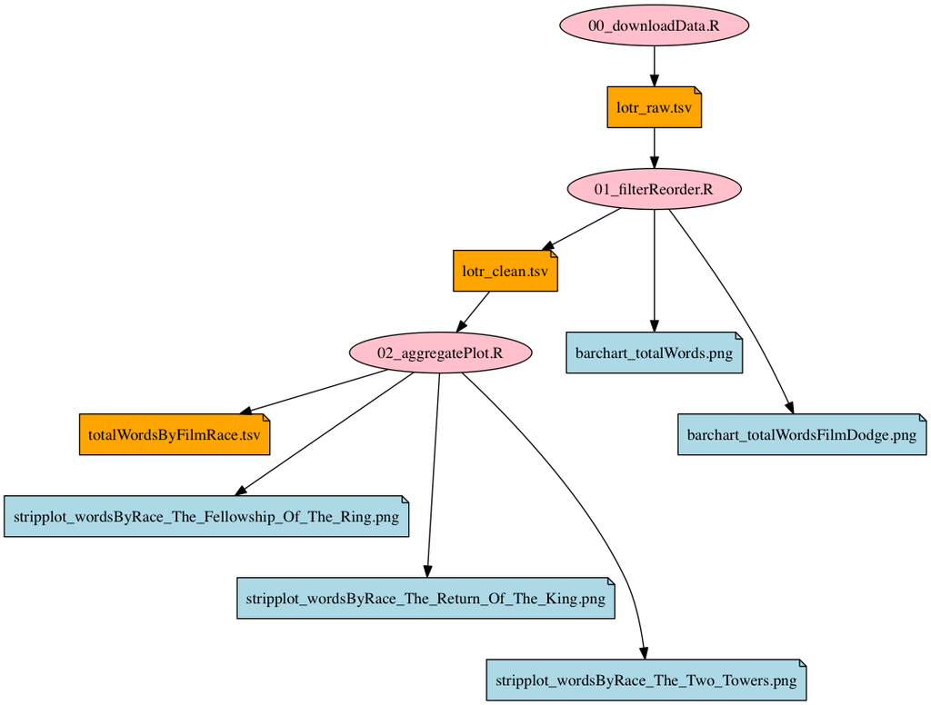

*01_justR*

- Only dependencies between scripts are shown.
- Data files are not shown.
- Run the scripts in *topographical* order.

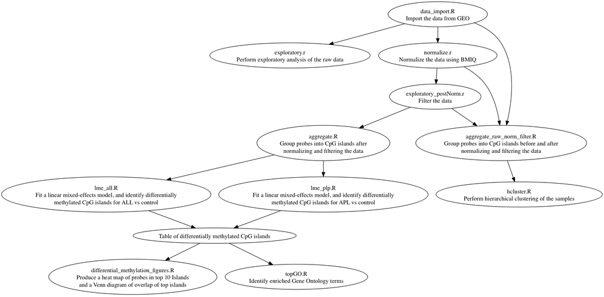

*STAT 540 Differential Methylation in Leukemia*

## Order of dependencies

A shell script gives *one* order in which you can successfully run the pipeline.

. . .

Unless the pipeline is completely linear, there are likely other such orders.

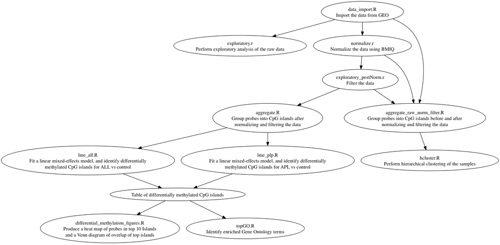

A different order of commands may be more convenient, but without information of the dependencies, you’re stuck with the given order.

# A reproducible manuscript

## One Makefile

- Downloads the data
- Runs the command-line programs
- Performs the statistical analyses using [R](http://tryr.codeschool.com/)
- and Generates the TSV tables
- Renders the figures using [ggplot2](http://ggplot2.org/)
- Renders the supplementary material using [RMarkdown](http://rmarkdown.rstudio.com/)
- Renders the manuscript using [Pandoc](http://johnmacfarlane.net/pandoc/)

## Turns this

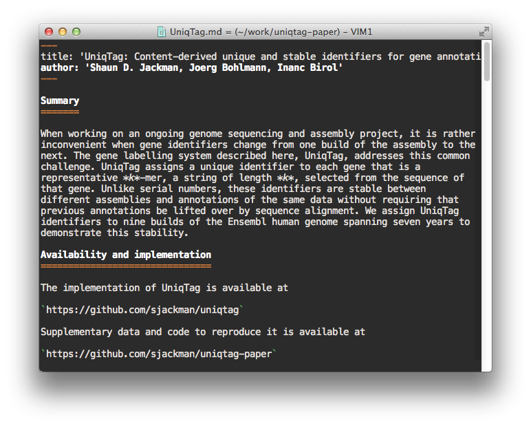

## Into this

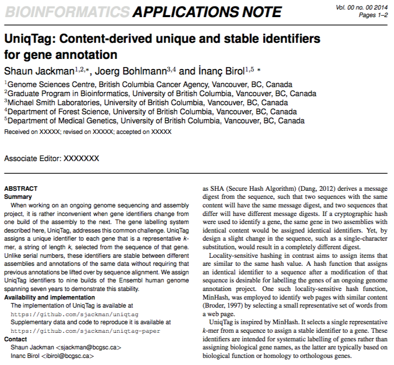

# Workflow

[Plain Text, Papers, Pandoc](http://kieranhealy.org/blog/archives/2014/01/23/plain-text/) by [Kieran Healy](http://kieranhealy.org/)

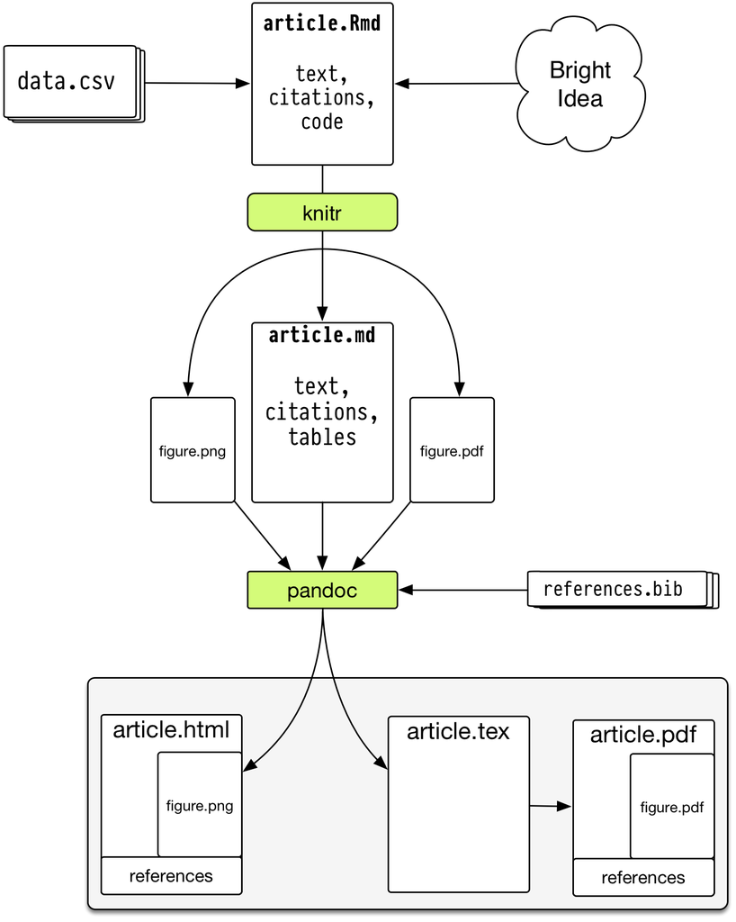

## Markdown for the manuscript

[Markdown](https://help.github.com/articles/markdown-basics/) is a plain-text typesetting language

```markdown
A header
========

A list:

+ This text is *italic*
+ This text is **bold**
```

### A header

A list:

- This text is *italic*
- This text is **bold**

## RMarkdown

- [RMarkdown](http://rmarkdown.rstudio.com/) interleaves prose with [R](http://tryr.codeschool.com/) code
  - to aggregate and summarize the data
  - to generate tables
  - to render figures using [ggplot2](http://ggplot2.org/)
- [RMarkdown](http://rmarkdown.rstudio.com/) is ideal for supplementary material

## RMarkdown example

````
The Sum of 1 + 1
================

The sum of 1 + 1 is calculated as follows.

```{r}
1 + 1
```

![*Fig. 1*: A graphical view of 1 + 1](figure.png)
````

*article.Rmd*

## The Sum of 1 + 1

The sum of 1 + 1 is calculated as follows.

```r
1 + 1
```

```
## [1] 2
```

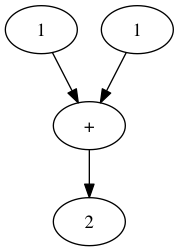

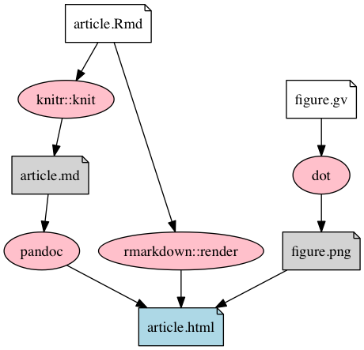

Dependencies of *article/Makefile*

## Render HTML

```
%.md: %.Rmd
    Rscript -e 'knitr::knit("$<", "$@")'

%.html: %.md
    pandoc -s -o $@ $<

%.html: %.Rmd
    Rscript -e 'rmarkdown::render("$<")'

article.html: figure.png

%.png: %.gv
    dot -Tpng $< >$@
```

```bash
make article.html
```

```bash
dot -Tpng figure.gv >figure.png
Rscript -e 'rmarkdown::render("article.Rmd")'
```

## Knit Markdown

```
%.md: %.Rmd
    Rscript -e 'knitr::knit("$<", "$@")'

%.html: %.md
    pandoc -s -o $@ $<

%.html: %.Rmd
    Rscript -e 'rmarkdown::render("$<")'

article.html: figure.png

%.png: %.gv
    dot -Tpng $< >$@
```

```bash
make article.md article.html
```

```bash
Rscript -e 'knitr::knit("article.Rmd", "article.md")'
dot -Tpng figure.gv >figure.png
pandoc -s -o article.html article.md
```

## Pandoc

[Pandoc](http://johnmacfarlane.net/pandoc/) renders attractive documents and slides  
from plain-text typesetting formats

It converts between every format known (just about)

- Markdown
- HTML
- LaTeX
- PDF
- ODT and docx (yes, really)

# Evolving a Makefile

```bash
#!/bin/sh
set -eux
dot -Tpng -o figure.png figure.gv
Rscript -e 'knitr::knit("article.Rmd")'
pandoc -s -o article.html article.md
```

Shell script

```
all:
    dot -Tpng -o figure.png figure.gv
    Rscript -e 'knitr::knit("article.Rmd")'
    pandoc -s -o article.html article.md
```

First Makefile

```
all: article.html

article.html:
    dot -Tpng -o figure.png figure.gv
    Rscript -e 'knitr::knit("article.Rmd")'
    pandoc -s -o article.html article.md
```

Add a rule to build `article.html`

```
all: article.html

article.html: article.Rmd
    dot -Tpng -o figure.png figure.gv
    Rscript -e 'knitr::knit("article.Rmd")'
    pandoc -s -o article.html article.md
```

`article.html` depends on `article.Rmd`

```
all: article.html

figure.png: figure.gv
    dot -Tpng -o figure.png figure.gv

article.md: article.Rmd
    Rscript -e 'knitr::knit("article.Rmd")'

article.html: article.md figure.png
    pandoc -s -o article.html article.md
```

Split one rule into three

```
all: article.html

figure.png: figure.gv
    dot -Tpng -o $@ $<

article.md: article.Rmd
    Rscript -e 'knitr::knit("$<", "$@")'

article.html: article.md figure.png
    pandoc -s -o $@ $<
```

Use the variables `$<` and `$@` for the input and output file

```
all: article.html

%.png: %.gv
    dot -Tpng -o $@ $<

%.md: %.Rmd
    Rscript -e 'knitr::knit("$<", "$@")'

article.html: article.md figure.png
    pandoc -s -o $@ $<
```

Use pattern rules. The `%` matches any string

```
all: article.html

%.png: %.gv
    dot -Tpng -o $@ $<

%.md: %.Rmd
    Rscript -e 'knitr::knit("$<", "$@")'

%.html: %.md
    pandoc -s -o $@ $<

article.html: figure.png
```

`article.html` also depends on `figure.png`

```
all: article.html

clean:
    rm -f article.md article.html figure.png

%.png: %.gv
    dot -Tpng -o $@ $<

%.md: %.Rmd
    Rscript -e 'knitr::knit("$<", "$@")'

%.html: %.md
    pandoc -s -o $@ $<

article.html: figure.png
```

Add the target named `clean`

```
all: article.html

clean:
    rm -f article.md article.html figure.png

.PHONY: all clean
.DELETE_ON_ERROR:
.SECONDARY:

%.png: %.gv
    dot -Tpng -o $@ $<

%.md: %.Rmd
    Rscript -e 'knitr::knit("$<", "$@")'

%.html: %.md
    pandoc -s -o $@ $<

article.html: figure.png
```

Add `.PHONY`, `.DELETE_ON_ERROR` and `.SECONDARY`

```
all: article.html

clean:
    rm -f article.md article.html figure.png

.PHONY: all clean
.DELETE_ON_ERROR:
.SECONDARY:

# Render a GraphViz file
%.png: %.gv
    dot -Tpng -o $@ $<

# Knit a RMarkdown document
%.md: %.Rmd
    Rscript -e 'knitr::knit("$<", "$@")'

# Render a Markdown document to HTML
%.html: %.md
    pandoc -s -o $@ $<

# Dependencies on figures
article.html: figure.png
```

# fin

## Links

[STAT 545A](http://stat545-ubc.github.io/) | [xkcd automation](http://xkcd.com/1319/)  
[R](http://tryr.codeschool.com/) | [Rscript](https://stat.ethz.ch/R-manual/R-devel/library/utils/html/Rscript.html) | [shell](http://en.wikipedia.org/wiki/Shell_script) | make  
[Markdown](https://help.github.com/articles/markdown-basics/) | [RMarkdown](http://rmarkdown.rstudio.com/) | [Pandoc](http://johnmacfarlane.net/pandoc/) | [ggplot2](http://ggplot2.org/)  
[Plain Text, Papers, Pandoc](http://kieranhealy.org/blog/archives/2014/01/23/plain-text/)  
[STAT 540 Differential Methylation in Leukemia](https://sites.google.com/site/stat540diffmethleuk/code)

[@sjackman](http://twitter.com/sjackman) | github.com/sjackman | sjackman.ca

## Shaun Jackman

[Genome Sciences Centre](http://bcgsc.ca), BC Cancer Agency  
Vancouver, Canada  
[@sjackman](http://twitter.com/sjackman)  
github.com/sjackman  
sjackman.ca

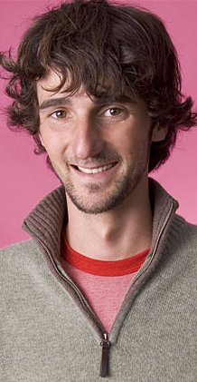